# Composition Analysis of the Bibliography of the Hand Press Books in Flanders dated 2025-11-05

# Overall summary

29,616 records and 2,618,074 attribute values in total. Constituent files:

- data/stcv/stcv.parquet (7.32MB)

## Temporal overview

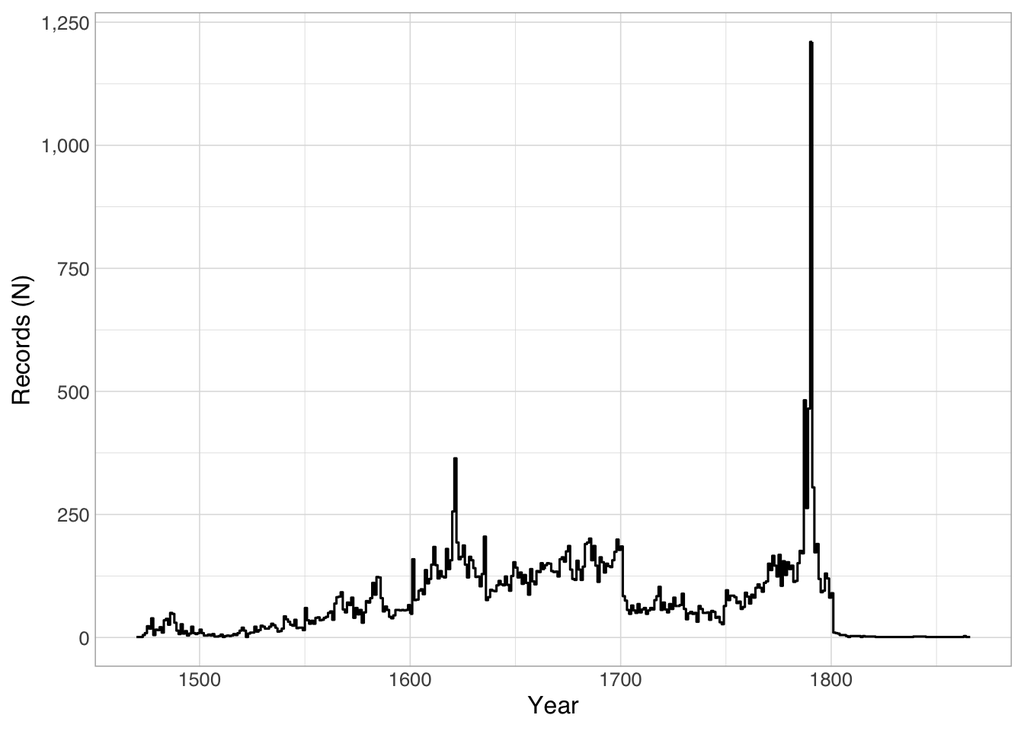

425 records do not have easily parseable dates between the years 1000 and 2050.

## Language overview

| [] | Records (N) | Proportion (%) |
| --- | --- | --- |
| dut (Dutch; Flemish) | 14312 | 0.483252296056186 |
| lat (Latin) | 9742 | 0.328943814154511 |
| fre (French) | 5129 | 0.17318341437061 |
| spa (Spanish; Castilian) | 224 | 0.0075634792004322 |
| eng (English) | 82 | 0.0027687736358725 |
| ita (Italian) | 64 | 0.00216099405726634 |
| grc (Greek, Ancient (to 1453)) | 41 | 0.00138438681793625 |
| ger (German) | 10 | 0.000337655321447866 |
| heb (Hebrew) | 6 | 0.00020259319286872 |
| por (Portuguese) | 2 | 6.75310642895732e-05 |

[output cut: 4 more lines]

# Field code usage overview

In total, 33 distinct fields are used.

Legend for the table below:

- `records`: how many records have at least one of this field
- `r_p`: the above as a percentage of all records
- `n`: the total number of appearances of this field
- `vals_per_rec`: calculated from the above, the mean number of appearances of this field per record
- `recs_with_mult_vals`: the number of records that have more than one repetition of this field

| field_code | field_description | records | r_p | n | vals_per_rec | recs_with_mult_vals |
| --- | --- | --- | --- | --- | --- | --- |
| <a name="001" href="https://www.loc.gov/marc/bibliographic/bd001.html">001</a> | Control Number | 29616 | 1 | 29616 | 1 | 0 |
| <a name="003" href="https://www.loc.gov/marc/bibliographic/bd003.html">003</a> | Control Number Identifier | 29616 | 1 | 29616 | 1 | 0 |
| <a name="005" href="https://www.loc.gov/marc/bibliographic/bd005.html">005</a> | Date and Time of Latest Transaction | 29616 | 1 | 29616 | 1 | 0 |
| <a name="008" href="https://www.loc.gov/marc/bibliographic/bd008.html">008</a> | General Information | 29616 | 1 | 29616 | 1 | 0 |
| <a name="026" href="https://www.loc.gov/marc/bibliographic/bd026.html">026</a> | Fingerprint Identifier | 29582 | 0.998851971907077 | 66342 | 2.24264755594618 | 29582 |
| <a name="040" href="https://www.loc.gov/marc/bibliographic/bd040.html">040</a> | Cataloging Source | 29616 | 1 | 88848 | 3 | 29616 |
| <a name="041" href="https://www.loc.gov/marc/bibliographic/bd041.html">041</a> | Language Code | 29616 | 1 | 34604 | 1.1684224743382 | 4168 |
| <a name="100" href="https://www.loc.gov/marc/bibliographic/bd100.html">100</a> | Main Entry - Personal Name | 17348 | 0.585764451647758 | 83922 | 4.83756052570902 | 17348 |
| <a name="110" href="https://www.loc.gov/marc/bibliographic/bd110.html">110</a> | Main Entry - Corporate Name | 4012 | 0.135467314964884 | 16323 | 4.0685443668993 | 4012 |
| <a name="130" href="https://www.loc.gov/marc/bibliographic/bd130.html">130</a> | Main Entry - Uniform Title | 579 | 0.0195502431118314 | 2316 | 4 | 579 |

[output cut: 23 more lines]

# Field code usage overview by subfield

In total, 110 distinct field+subfield combinations are used.

Legend for the table below:

- `records`: how many records have at least one of this field+subfield
- `r_p`: the above as a percentage of all records
- `dist_vals`: the number of different values appearing in this field+subfield
- `e_vals`: at most seven random sample values of this field+subfield
- `n`: the total number of appearances of this field+subfield
- `vals_per_rec`: calculated from the above, the mean number of appearances of this field+subfield per record
- `recs_with_mult_vals`: the number of records that have more than one repetition of this field+subfield

| subfield_code | subfield_description | records | r_p | dist_vals | e_vals | n | vals_per_rec | recs_with_mult_vals |
| --- | --- | --- | --- | --- | --- | --- | --- | --- |
| [001: Control Number](https://www.loc.gov/marc/bibliographic/bd001.html) |  |  |  |  |  |  |  |  |
| 001$ | NA | 29,616 | 100% | 29,616 | c:stcv:3118747 (1)\|c:stcv:12928461 (1)\|c:stcv:12912524 (1)\|c:stcv:6152600 (1)\|c:stcv:7032156 (1)\|c:stcv:6848627 (1)\|c:stcv:12922515 (1) | 29,616 | 1 | 0 |
| [003: Control Number Identifier](https://www.loc.gov/marc/bibliographic/bd003.html) |  |  |  |  |  |  |  |  |
| 003$ | NA | 29,616 | 100% | 1 | BE-VEB01 (29616) | 29,616 | 1 | 0 |
| [005: Date and Time of Latest Transaction](https://www.loc.gov/marc/bibliographic/bd005.html) |  |  |  |  |  |  |  |  |
| 005$ | NA | 29,616 | 100% | 1,429 | 20240828000000.1 (3)\|20170717000000.1 (1)\|20160920000000.1 (1)\|20250612000000.1 (18)\|20180118000000.1 (1)\|20201016000000.1 (1)\|20240219000000.1 (1) | 29,616 | 1 | 0 |
| [008: General Information](https://www.loc.gov/marc/bibliographic/bd008.html) |  |  |  |  |  |  |  |  |
| 008$ | NA | 29,616 | 100% | 21,898 | 110111s1536####xx u lat (1)\|100303s1659####xx u fre (1)\|121031s1566####xx u dut (1)\|091021s1663####xx u lat (2)\|130812s1752####xx u fre (1)\|090115s1761####xx u fre (1)\|180813s1717####xx u dut (1… | 29,616 | 1 | 0 |
| [026: Fingerprint Identifier](https://www.loc.gov/marc/bibliographic/bd026.html) |  |  |  |  |  |  |  |  |
| 026$2 | NA | 29,582 | 99.89% | 1 | stcnf (33171) | 33,171 | 1.12 | 2,208 |
| 026$e | NA | 29,582 | 99.89% | 32,241 | 000008 - # b1 A2 yt$ : # b2 C2 $h (1)\|169118 - # b1 .$C : # b2 C $ (1)\|178708 - # b1 Transit $en$g : # b2 Janvier $17$D (1)\|000008 - # b1=b2 EUPEN R$NO (1)\|163108 - # b1 A4 ur$de : # b2 V4 e$c (1)… | 33,171 | 1.12 | 2,208 |
| [040: Cataloging Source](https://www.loc.gov/marc/bibliographic/bd040.html) |  |  |  |  |  |  |  |  |
| 040$a | Original cataloging agency | 29,616 | 100% | 1 | BE-VEB01 (29616) | 29,616 | 1 | 0 |
| 040$b | Language of cataloging | 29,616 | 100% | 1 | eng (29616) | 29,616 | 1 | 0 |
| 040$c | Transcribing agency | 29,616 | 100% | 1 | BE-VEB01 (29616) | 29,616 | 1 | 0 |
| [041: Language Code](https://www.loc.gov/marc/bibliographic/bd041.html) |  |  |  |  |  |  |  |  |
| 041$a | Language code of text/sound track or separate title | 29,616 | 100% | 21 | dut (14861)\|hun (1)\|fre (5785)\|nds (1)\|arc (2)\|lat (10077)\|tur (1) | 31,584 | 1.07 | 1,603 |
| 041$h | Language code of original and/or intermediate translations of text | 2,778 | 9.38% | 15 | ger (242)\|heb (15)\|gre (2)\|fre (599)\|spa (339)\|dut (87)\|eng (26) | 2,858 | 1.03 | 64 |
| 041$k | NA | 142 | 0.48% | 9 | dut (4)\|ita (15)\|spa (9)\|eng (1)\|fre (75)\|lat (51)\|grc (1) | 162 | 1.14 | 20 |
| [100: Main Entry - Personal Name](https://www.loc.gov/marc/bibliographic/bd100.html) |  |  |  |  |  |  |  |  |
| 100$0 | NA | 17,282 | 58.35% | 8,034 | (BE-VEB01)a::920.138853:1.1 (1)\|(BE-VEB01)a::920.100548:1.10 (2)\|(BE-VEB01)a::920.74211:1.2 (3)\|(BE-VEB01)a::920.63180:1.1 (1)\|(BE-VEB01)a::920.7837:1.21 (2)\|(BE-VEB01)a::920.4652:1.9 (1)\|(BE-VE… | 17,282 | 1 | 0 |
| 100$4 | Relator code | 17,348 | 58.58% | 3 | dis (421)\|aut (16913)\|cmp (14) | 17,348 | 1 | 0 |
| 100$Y | NA | 17,348 | 58.58% | 2 | 3 (1)\|1 (17347) | 17,348 | 1 | 0 |
| 100$a | Personal name | 17,348 | 58.58% | 4,953 | person from Brabant (2)\|Goethals, Andreas (1)\|Juan de Segovia (1)\|Dodoens, Rembert (20)\|Rombaut, J.A. (1)\|Lenaerts, Petrus (1)\|de Bernières-Louvigny, Jean (7) | 17,348 | 1 | 0 |
| 100$c | Titles and other words associated with a name | 1,726 | 5.83% | 65 | Madame (1)\|Prince of Wales (1)\|baron (4)\|Prince of Orange (8)\|Regent of the Netherlands (16)\|prince-bishop of Liege (2)\|King of Naples and Sicily (1) | 1,726 | 1 | 0 |
| 100$d | Dates associated with a name | 12,870 | 43.46% | 2,472 | 1603-1638 (1)\|c.560-636 (4)\|1637-1707 (3)\|1563-1621 (1)\|1566-1622 (1)\|1527-1591 (3)\|1644-1718 (1) | 12,870 | 1 | 0 |
| [110: Main Entry - Corporate Name](https://www.loc.gov/marc/bibliographic/bd110.html) |  |  |  |  |  |  |  |  |
| 110$0 | NA | 4,012 | 13.55% | 990 | (BE-VEB01)a::061.95571:1.2 (1)\|(BE-VEB01)a::061.6720:1.1 (1)\|(BE-VEB01)a::061.81638:1.13 (14)\|(BE-VEB01)a::061.82896:1.15 (1)\|(BE-VEB01)a::061.93865:1.1 (1)\|(BE-VEB01)a::061.89982:1:N (1)\|(BE-VE… | 4,012 | 1 | 0 |
| 110$4 | Relator code | 4,012 | 13.55% | 1 | aut (4012) | 4,012 | 1 | 0 |
| 110$Y | NA | 4,012 | 13.55% | 1 | 2 (4012) | 4,012 | 1 | 0 |

[output cut: 113 more lines]